# lab2

```r
library(lme4)
library(dplyr)
```

### Data description

The average reaction time per day for subjects in a sleep deprivation study. On day 0 the subjects had their normal amount of sleep. Starting that night they were restricted to 3 hours of sleep per night. The observations represent the average reaction time on a series of tests given each day to each subject.

A data frame with 180 observations on the following 3 variables.

Reaction: Average reaction time (ms)

Days: Number of days of sleep deprivation

Subject: Subject number on which the observation was made.

```r
str(sleepstudy)
```

```
## 'data.frame':    180 obs. of  3 variables:
##  $ Reaction: num  250 259 251 321 357 ...
##  $ Days    : num  0 1 2 3 4 5 6 7 8 9 ...
##  $ Subject : Factor w/ 18 levels "308","309","310",..: 1 1 1 1 1 1 1 1 1 1 ...
```

```r
require(lattice)
table(sleepstudy$Subject) # 18 different subjects, each with 10 measurements
```

```
##
## 308 309 310 330 331 332 333 334 335 337 349 350 351 352 369 370 371 372
##  10  10  10  10  10  10  10  10  10  10  10  10  10  10  10  10  10  10
```

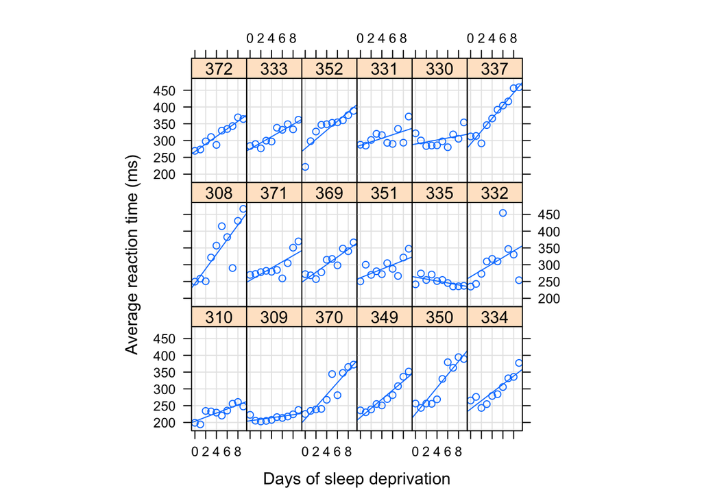

```r
xyplot(Reaction ~ Days | Subject, sleepstudy, type = c("g","p","r"),
       index = function(x,y) coef(lm(y ~ x))[1],
       xlab = "Days of sleep deprivation",
       ylab = "Average reaction time (ms)", aspect = "xy")
```

Each subject’s reaction time increases approximately linearly with the number of sleepdeprived days. However, subjects also appear to vary in the slopes and intercepts of these relationships, which suggests a model with random slopes and intercepts. As we shall see, such a model may be fitted by minimizing the REML criterion:

```r
fm1 <- lmer(Reaction ~ Days + (Days|Subject), sleepstudy)
summary(fm1)
```

```
## Linear mixed model fit by REML ['lmerMod']
## Formula: Reaction ~ Days + (Days | Subject)
##    Data: sleepstudy
##
## REML criterion at convergence: 1743.6
##
## Scaled residuals:
##     Min      1Q  Median      3Q     Max
## -3.9536 -0.4634  0.0231  0.4634  5.1793
##
## Random effects:
##  Groups   Name        Variance Std.Dev. Corr
##  Subject  (Intercept) 612.09   24.740
##           Days         35.07    5.922   0.07
##  Residual             654.94   25.592
## Number of obs: 180, groups:  Subject, 18
##
## Fixed effects:
##             Estimate Std. Error t value
## (Intercept)  251.405      6.825   36.84
## Days          10.467      1.546    6.77
##
## Correlation of Fixed Effects:
##      (Intr)
## Days -0.138
```

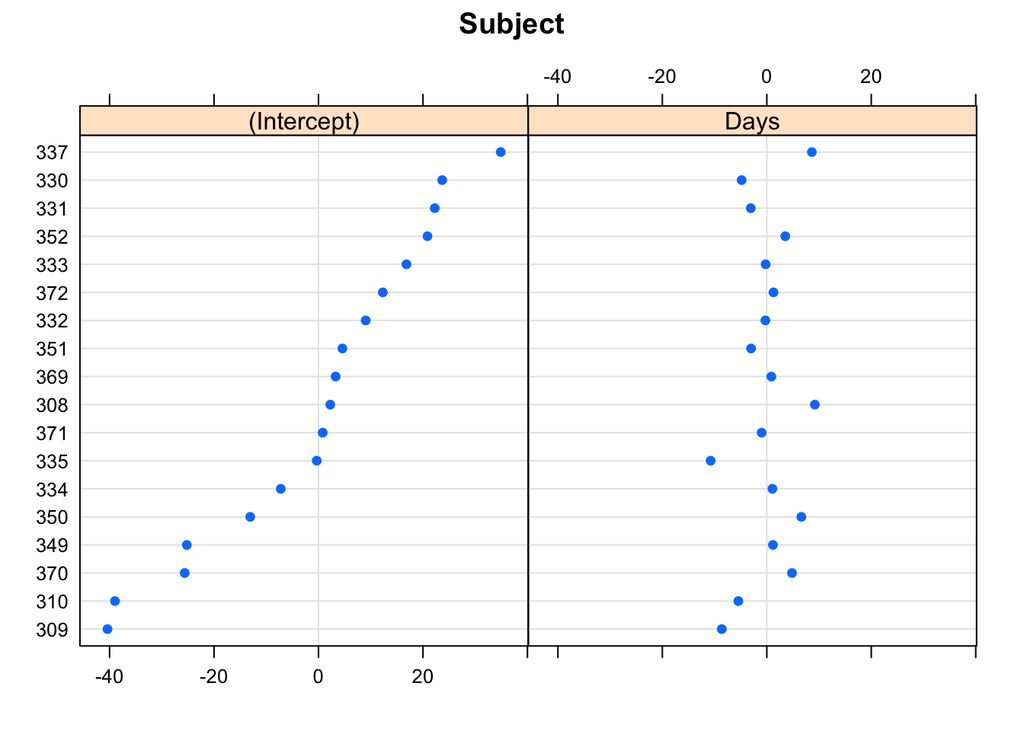

```r
u=ranef(fm1) # predicted random effects
dotplot(u)
```

```r
fixef(fm1) # fixed effects estimate
```

```
## (Intercept)        Days
##   251.40510    10.46729
```

```r
VarCorr(fm1) # covariance structure
```

```
##  Groups   Name        Std.Dev. Corr
##  Subject  (Intercept) 24.7404
##           Days         5.9221  0.066
##  Residual             25.5918
```

The estimates of the standard deviations of the random effects for the intercept and the slope are 24.74 ms and 5.92 ms/day. The fixed-effects coefficients, β, are 251.4 ms and 10.47 ms/day for the intercept and slope. In this model, one interpretation of these fixed effects is that they are the estimated population mean values of the random intercept and slope

```r
fm2 <- lmer(Reaction ~ Days + (1|Subject) + (0+Days|Subject), sleepstudy)
summary(fm2) %>% coef
```

```
##              Estimate Std. Error   t value
## (Intercept) 251.40510   6.885382 36.512879
## Days         10.46729   1.559566  6.711666
```

```r
fm3 <- lmer(Reaction ~ Days + (Days || Subject), sleepstudy)
summary(fm3) %>% coef
```

```
##              Estimate Std. Error   t value
## (Intercept) 251.40510   6.885382 36.512879
## Days         10.46729   1.559566  6.711666
```

```r
library(lmerTest)  #  Satterthwaite's df approximation
fm3 <- lmer(Reaction ~ Days + (Days || Subject), sleepstudy)
summary(fm3) %>% coef
```

```
##              Estimate Std. Error       df   t value     Pr(>|t|)
## (Intercept) 251.40510   6.885382 18.15619 36.512879 0.000000e+00
## Days         10.46729   1.559566 18.15621  6.711666 2.593944e-06
```